# Praca domowa

Katarzyna Fąk

08.03.2015

Porównaniu poddaję dwie kultowe produkcje roku 1994: **Króla Lwa** oraz **Forresta Gumpa**. Podstawowe informacje i opinie o filmach znajdowałam na stronach: wikipedii oraz filmwebu:

- [Król Lew - filmweb.pl](http://www.filmweb.pl/Krol.Lew)
- [Forrest Gump - filmweb.pl](http://www.filmweb.pl/Forrest.Gump)
- [Król Lew - pl.wikipedia.org](http://pl.wikipedia.org/wiki/Kr%C3%B3l_Lew)
- [Forrest Gump - pl.wikipedia.org](http://pl.wikipedia.org/wiki/Forrest_Gump_%28film%29)

Potrzebne biblioteki:

```r
library(rvest)
library(stringi)
library(XML)
```

Adresy stron, z których będziemy korzystać:

```r
krol.lew.fw <- "http://www.filmweb.pl/Krol.Lew"
krol.lew.w <- "http://pl.wikipedia.org/wiki/Kr%C3%B3l_Lew"
forrest.gump.fw <- "http://www.filmweb.pl/Forrest.Gump"
forrest.gump.w <- "http://pl.wikipedia.org/wiki/Forrest_Gump_%28film%29"
```

# Forrest Gump i Król Lew - podstawowe informacje

## Opisy producentów

```r
opisy <- function(title_html){
      cast <- html_nodes(html(title_html), "div p.text") #wezel.klasa
      teksty <- html_text(cast)
      return(teksty[1])
}

opisy(forrest.gump.fw)
```

```
## [1] "Historia życia Forresta, chłopca o niskim ilorazie inteligencji z niedowładem kończyn, który staje się miliarderem i bohaterem wojny w Wietnamie."
```

```r
opisy(krol.lew.fw)
```

```
## [1] "Targany niesłusznymi wyrzutami sumienia po śmierci ojca mały lew Simba skazuje się na wygnanie rezygnując z przynależnego mu miejsca na czele stada."
```

## Oceny i popularność

```r
cast <- html_nodes(html(forrest.gump.fw), "div div.ratingInfo")
(ratingInfo <- html_text(cast))
```

```
## [1] "  8,6 676 858 głosów56 489 chce zobaczyć"
```

To surowa informacja, jednak łatwo można ją “obrobić” w zrozumiały sposób:

```r
cat("Ocena:",
    stri_extract_all_regex(ratingInfo, "[0-9]+,[0-9]")[[1]],
    "na",
    stri_extract_first_regex(ratingInfo, "[0-9]+ [0-9]+ \\p{L}+")[[1]],
    "-",
    stri_extract_last_regex(ratingInfo, "[0-9]+ [0-9]+ \\p{L}+ \\p{L}+")[[1]],
    "ów film."
)
```

```
## Ocena: 8,6 na 676 858 głosów - 56 489 chce zobaczyć ów film.
```

Kod jest na tyle uniwersalny, że zadziała również na klasyku Walta Disneya oraz innych filmach z filmweb.pl

```
## [1] "  8,3 368 793 głosy12 307 chce zobaczyć"
```

```
## Ocena: 8,3 na 368 793 głosy - 12 307 chce zobaczyć ów film.
```

# Podstawowe dane

Podstawowe dane pochodzą z portalu pl.wikipedia.org, w którym na stronach większości filmów można znaleźć zwięzłe i przejrzyste tabelki.

```r
tabele <- readHTMLTable(html(forrest.gump.w), stringsAsFactors = FALSE)
forrest_info <- tabele[[1]][c(2:12,14:18),]
row.names(forrest_info) <- NULL

tabele <- readHTMLTable(html(krol.lew.w), stringsAsFactors = FALSE)
krol_info <- tabele[[2]][1:14,]

print(forrest_info)
```

```
##                V1                                                    V2
## 1         Gatunek                                         komediodramat
## 2   Data premiery                                          6 lipca 1994
## 3  Kraj produkcji                                     Stany Zjednoczone
## 4           Język                                             angielski
## 5    Czas trwania                                             141 minut
## 6       Reżyseria                                       Robert Zemeckis
## 7      Scenariusz                                             Eric Roth
## 8     Główne role      Tom HanksRobin Wright PennGary SiniseSally Field
## 9          Muzyka                                        Alan Silvestri
## 10        Zdjęcia                                           Don Burgess
## 11    Scenografia                                           Nancy Haigh
## 12         Montaż                                        Arthur Schmidt
## 13      Produkcja Wendy FinermanCharles NewirthSteve StarkeySteve Tisch
## 14      Wytwórnia                                    Paramount Pictures
## 15    Dystrybucja                                    Paramount Pictures
## 16         Budżet                                        55 000 000 USD
```

Dzięki pobranym tabelom możemy uzyskać dowolną podstawową informację na temat obu filmów w bardzo prosty sposób. Obrazują to dwa poniższe przykłady:

**Reżyseria:**

```r
(krol_info[krol_info[,1]=="Reżyseria",2])
```

```
## [1] "Roger Allers,Rob Minkoff"
```

```r
(forrest_info[forrest_info[,1]=="Reżyseria",2])
```

```
## [1] "Robert Zemeckis"
```

**W rolach (głosach?) głównych:**

```r
(KL <- unlist(
      stri_extract_all_regex(
            krol_info[krol_info[,1]=="Główne role",2],
      "[A-Z][a-z]+ [A-Z][a-z]+")))
```

```
##  [1] "Matthew Broderick" "Jeremy Irons"      "James Earl"
##  [4] "Jonathan Taylor"   "Nathan Lane"       "Ernie Sabella"
##  [7] "Moira Kelly"       "Robert Guillaume"  "Rowan Atkinson"
## [10] "Whoopi Goldberg"   "Cheech Marin"      "Jim Cummings"
```

```r
(FG <- unlist(
      stri_extract_all_regex(
            forrest_info[forrest_info[,1]=="Główne role",2],
      "[A-Z][a-z]+ [A-Z][a-z]+")))
```

```
## [1] "Tom Hanks"    "Robin Wright" "Gary Sinise"  "Sally Field"
```

**Czy któryś z głównych aktorów z Forresta Gumpa podkładał głos do Króla Lwa?**

```r
FG%in%KL
```

```
## [1] FALSE FALSE FALSE FALSE
```

# Opinie

Ciekawszą rzeczą będzie przyjrzenie się recenzjom obu filmów. Ich pobranie uprzedzić musi analiza odnośników prowadzących do odpowiednich tekstów. Poniższa funkcja pomoże nam wyciągać odpowiednie teksty i zapisywać je do wektora.

```r
recenzje <- function(film){
      # stop if not (...)
      # parsowanie strony:
      html <- html(paste0(film,"/reviews"))
      cast <- html_nodes(html, "h3 a")
      # schowek na recenzje:
      reviews <- numeric(length(cast))
            # wydłubywanie recenzji
            for(i in seq_along(cast)){
                  href <- html_attrs(cast[[i]])
                  html1 <- html(paste0("http://www.filmweb.pl",href))
                  cast1 <- html_nodes(html1,"div.normal")
                  reviews[i] <- html_text(cast1)
            }
      return(reviews)
}
```

```r
forrest_gump_reviews <- recenzje(forrest.gump.fw)
lion_king_reviews <- recenzje(krol.lew.fw)
```

Jak to wygląda? (na przykładzie wybranej recenzji)

```r
lion_king_reviews[1]
```

```
## [1] "Legenda powraca. By zarobić jeszcze więcej. Na szczęście nie w jednym ze słabych sequeli, z którymi studio Disneya niszczy od lat dziecięce gusta. \"Król Lew\" doczekał się dwóch takich kontynuacji, ale  teraz, po 17 latach swoją drugą szansę w kinach dostaje oryginalny film z 1994 roku – ty…
```

Teksty takie mogą przydać się do analizy wydźwięku treści. Wykorzystując odpowiednie techniki możemy ocenić popularność danego filmu i emocje, jakie wywołuje. Oto jak (moim zdaniem) **nie** powinno się tego robić.

```r
lion_king_reviews <- stri_trans_tolower(lion_king_reviews)
slowa <- unlist(stri_extract_all_words(lion_king_reviews))
# pierwszych 50 k'woli prezentacji. Naturalnie, jest ich więcej.
table(slowa[1:50])
```

```
##
##                17              1994               ale                by
##                 1                 1                 1                 1
##           disneya                do          doczekał           dostaje
##                 1                 1                 1                 1
##             drugą             dwóch         dziecięce              film
##                 1                 1                 1                 1
##             gusta            jednym           jeszcze            kinach
##                 1                 1                 1                 1
##       kontynuacji              król           którymi               lat
##                 1                 1                 1                 1
##            latach           legenda               lew                na
##                 1                 1                 1                 1
##               nie           niszczy                od        oryginalny
##                 1                 1                 1                 1
##                po           powraca przetransferowany              roku
##                 1                 1                 1                 1
##           sequeli               się           słabych            studio
##                 1                 1                 1                 1
##             swoją            szansę         szczęście            takich
##                 1                 1                 1                 1
##             teraz              tyle                 w            więcej
##                 1                 1                 2                 1
##                 z           zarobić                ze                że
##                 2                 1                 1                 1
```

```r
# Polski słownik wydźwięku: http://zil.ipipan.waw.pl/SlownikWydzwieku
download.file("http://zil.ipipan.waw.pl/SlownikWydzwieku?action=AttachFile&do=get&target=slownikWydzwieku01.csv","slownik")
slownik <- read.csv("slownik",sep="\t",h=FALSE)[,c(1,5)]
```

Pobrany słownik ocenia wydźwięk słowa w skali [-2, 2] [negatywny,pozytywny].

Słowa występujące w naszym słowniku:

```r
slowa_w_slowniku <- table(slowa[slowa%in%slownik[,1]])
```

10.08% słów z naszych recenzji jest w słowniku. Wydźwięk z wszystkich recenzji:

```r
vec <- setNames(slownik[,2],slownik[,1])
w <- vec[names(slowa_w_slowniku)]%*%slowa_w_slowniku
as.numeric(w)
```

```
## [1] 185
```

co (sprowadzając do skali [-2,2]) wynosi: **0.2380952**.

Analogiczne postępowanie dla Forresta Gumpa zwróci nam wartość **0.2765568**.

# Opinie z Twittera

Bardzo wiele z pobranych tweetów się powtarza, w efekcie z 1000 rekordów bywa, że pozostaje ich mniej niż połowa. Następująca funkcja służy do analizowania wydźwięku tweetów. Posłużyłam się [tym oto](http://www2.compute.dtu.dk/pubdb/views/edoc_download.php/6010/zip/imm6010.zip) słownikiem. **Został on już automatycznie pobrany do katalogu /home/katarzyna/Dokumenty/Studia/studia/R++**.

```r
# funkcja do liczenia sentymentu z Tweetera, dla dowolnego tytulu.
# n - liczba tweetow do wyszukania.
sentiment_tweeter <- function(tytul,n){
      require(stringi)
      require(twitteR)
      setup_twitter_oauth(consumerKey, consumerSecret, access_token, access_secret)

      tweets <- searchTwitter(tytul,n)
      df_tweets <- twListToDF(tweets)
      data0 <- unique(df_tweets$text)

      # data cleaning
      data <- stri_replace_all_regex(data0, "(RT|via)((?:\\b\\W*@\\w+)+)","")   # usuwanie RT z poczatkow
      data <- stri_replace_all_regex(data, "@\\w+","")                         # usuwanie nazw @...
      data <- stri_replace_all_regex(data, "http(s)*://[^ ]+","")              # usuwanie linkow
      data <- stri_replace_all_regex(data, "#[^ ]+","")                        # usuwanie nazw #...
      data <- stri_trans_tolower(data)
      data <- unlist(stri_extract_all_words(data))

      #sentiment
      words <- table(data[data%in%eng_words[,1]]) # dziadowy słownik: ze 123 wyrazów znalazł jedynie 7 z nich...
      vec <- setNames(eng_words[,2],eng_words[,1])
      sentiment <- vec[names(words)]%*%words
      # czyli wydźwięk danego słowa * liczba jego wystąpień. Sumujemy po współrzędnych.
      cat("Liczba użytych tweetów: ", length(data0), " na ", n, ".")
      return(as.integer(sentiment)/(sum(words)))
      }
```

W efekcie (*uśredniony*) wydźwięk poszczególnych filmów jest następujący (słownik oceniał każdy wyraz w skali [-5, 5]):

```r
sentiment_tweeter("The Lion King",300)
```

```
## [1] "Using direct authentication"
## Liczba użytych tweetów:  158  na  300 .
```

```
## [1] 0.1493506
```

```r
sentiment_tweeter("Forrest Gump",300)
```

```
## [1] "Using direct authentication"
## Liczba użytych tweetów:  226  na  300 .
```

```
## [1] 0.5
```

# NGramy

Wiedzy o popularności danych filmów dostarczą nam również NGramy firmy Google. Korzystając z udostępnionych baz danych zobaczymy, jak zmieniała się popularność tytułów filmów w literaturze anglojęzycznej. Niestety dane danych bazy sięgają jedynie 2008 roku.

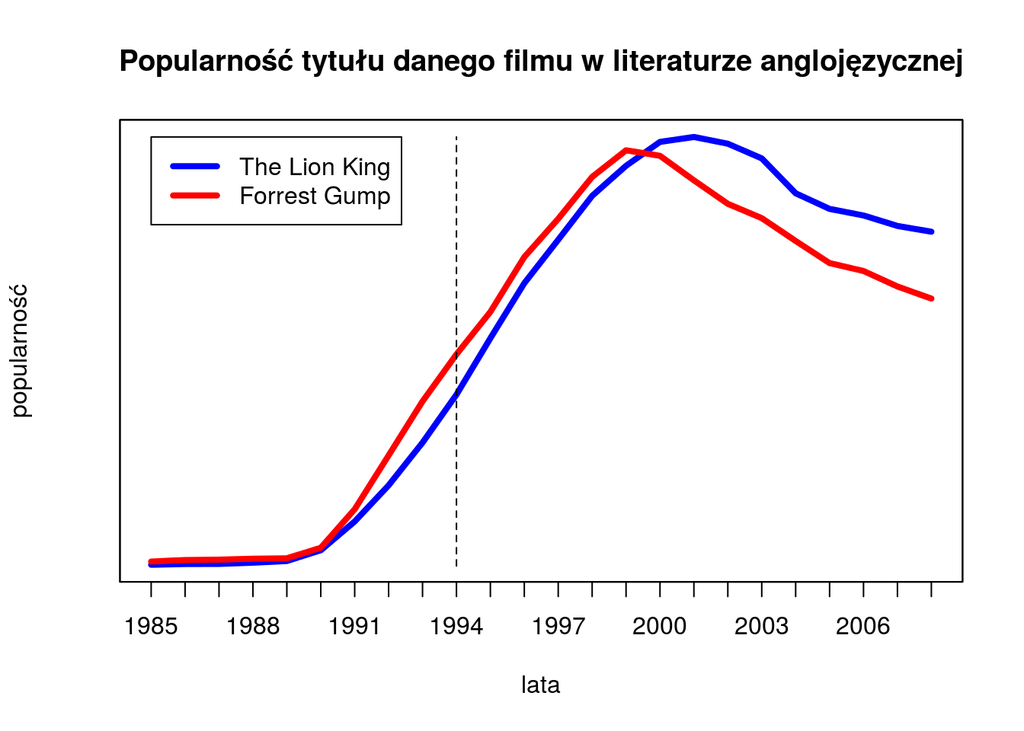

```r
# starałam się, by jak najbardziej zuniwersalizować(?) kod, tak by tytuł jedynie wystarczył do wyświetlenia wykresu. Nad postacią linku (by generował się sam, po tytule) da się popracować, ale to już chyba zagadnienie na inny dzień... :) Podobnie pionową oś wskazującą na rok produkcji można łatwo dodać, wykorzystując uzyskane już dane: wiedząc to poszłam po mniejszej lini oporu, skupiając się na tym, co istotne ;]
link <- "https://books.google.com/ngrams/graph?content=The+Lion+King%2CForrest+Gump&year_start=1985&year_end=2008&corpus=17&smoothing=4&share=&direct_url=t1%3B%2CThe%20Lion%20King%3B%2Cc0%3B.t1%3B%2CForrest%20Gump%3B%2Cc0"
#parsowanie
cast <- html_nodes(html(link), "script")

# wydobycie informacji o zakresie osi odciętych
t_axis <- as.numeric(
      stri_split_regex(
            na.omit(unlist(stri_extract_all_regex(html_text(cast),"[0-9]{4}, [0-9]{4}, [0-9]+\\.[0-9]+"))),
      ", ")[[1]])
t <- seq(from = t_axis[1], to = t_axis[2], by = 1)

# informacje o poszczególnych szeregach czasowych
timeseries_raw <- stri_split_regex(
      na.omit(unlist(stri_extract_all_regex(html_text(cast), "var data .+"))),
      "\"ngram\": ")[[1]][-1]

y <- lapply(timeseries_raw, function(x){
      # wydłubanie wartości szeregów czasowych
      as.numeric(
      stri_extract_all_regex(x, "[0-9]+\\.[0-9]+(e-[0-9]+){0,1}")[[1]])
})
names_y <- stri_extract_first_regex(timeseries_raw,"[a-zA-Z ]+")
y_axis <- range(union(y[[1]],y[[2]]))           # rozpiętość na osi y.
plot(t, y[[1]], col = "blue", lwd=4, type="l",
     ylim = y_axis, xlab = "lata", ylab="popularność",yaxt="n", xaxp=c(t_axis[-3],t_axis[2]-t_axis[1]),
     main="Popularność tytułu danego filmu w literaturze anglojęzycznej")
par(new=TRUE)
plot(t, y[[2]], col = "red", lwd=4, type="l", ylim = y_axis, yaxt="n", xaxt="n",ylab="",xlab="")
lines(c(1994,1994),c(0,y_axis[2]),lty=2) # rok wydania obu filmów
legend(t[1],y_axis[2], names_y,col=c("blue","red"),lty=c(1,1),lwd=c(4,4))
```

> To byłoby na tyle. Nie wynikają stąd wielkie wnioski (obie produkcje są jednakowo popularne, choć wydawałoby się, że użytkownicy Tweetera mniej lubią Króla Lwa), ale też nie będąc pewną co dokładnie jest celem pracy domowej, za takowy postawiłam sobie pobawienie się nowopoznanymi funkcjami bardziej niż zmienienie nimi świata :)

PS. Są czadowe.